# File S10: Visualizing breakpoints in E. coli genome assemblies

Eric S. Tvedte

July 17, 2019

# Usage

De novo assemblies of Riptide libraries were followed by alignment of segments to the E. coli reference genome to assess the fragmentation of assemblies relative to conventional Illumina.

Unix commands are given in blue.

## 1. Assemble paired end data using SPAdes

spades.py -o SPAdes_assembly –pe1-1 R1.fastq.gz –pe1-2 R2.fastq.gz -m 300

## 2. Align contigs to E. coli reference using nucmer (MUMmer3)

nucmer –prefix NCBI Ecoli_HS_genome.fasta spades.contigs.fasta

delta-filter -q NCBI.delta > NCBI.filter

show-coords -rb NCBI.filter > NCBI.filter.coords

awk ‘{print $11}’ NCBI.filter.coords | tail -n +6 | sort -n | uniq > NCBI.match.list

xargs samtools faidx spades.contigs.fasta < NCBI.match.list >> matched_contigs.fasta

## 3. Similar alignment using only contigs with match to NCBI reference

nucmer –mum –minmatch 150 –prefix NCBI_match Ecoli_HS_genome.fasta matched_contigs.fasta

delta-filter -qr NCBI_match > NCBI_match.filter

show-coords -rb NCBI_match.filter > NCBI_match.coords

cat NCBI_match.coords | tail -n +6 | awk ‘{print $1“”$2}’ > NCBI_start+end.coords

## 4. Visualize data

Breakpoints were estimated by averaging the end coordinate of an assembly:reference alignment with the start coordinate of the subsequent alignment Colors and labels were edited for publication image

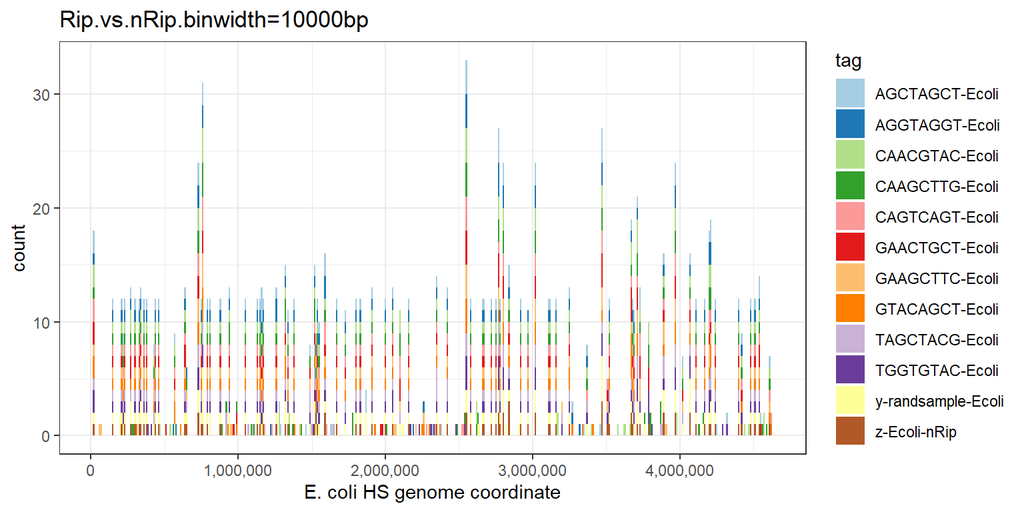

```r
library(ggplot2)
library(viridis)
library(scales)
setwd("Y:/RDRIP/etvedte/Denovo_assemblies/SPAdes_denovo/mummer/match_only/")
rip.path = "Y:/RDRIP/etvedte/Denovo_assemblies/SPAdes_denovo/mummer/match_only/"

fn <- dir(rip.path, pattern = "end.coords")


Graphing = data.frame()

for(i in 1:length(fn)){

#in.path = "Y:/RDRIP/etvedte/Denovo_assemblies/SPAdes_denovo/mummer/match_only/RDRIP_20180711_K00134_IL100105221_CAGTCAGT-Ecoli_NCBI_start+end.coords"
  data <- read.table(fn[i], header = F, sep = '\t')
  colnames(data) <- c("start", "end")

  data$avg <- with(data, c(end[1],start[-1]+end[-nrow(data)]) / 2)

  s.fn <- sub(".*221_", "", fn[i])
  data$tag <- sub("_N.*","", s.fn)

  f.data <- data[-1, ]
  Graphing<-rbind(Graphing,f.data)
}

nrip.path = "Y:/RDRIP/etvedte/non-RIPTIDE/Denovo_assemblies/RDRIP_20190111_K00134_IL100117483_MX6_L001_SPAdes_assembly/mummer/Ecoli_nRip_NCBI_start+end.coords"

data <- read.table(nrip.path, header = F, sep = '\t')
colnames(data) <- c("start", "end")

data$avg <- with(data, c(end[1],start[-1]+end[-nrow(data)]) / 2)
data$tag <- c("z-Ecoli-nRip")

f.data <- data[-1, ]
Graphing<-rbind(Graphing,f.data)

Graphing <- Graphing[order(Graphing$avg), ]
write.table(Graphing, file='Y:/RDRIP/etvedte/Denovo_assemblies/SPAdes_denovo/mummer/match_only/Ecoli.assembly.breaks.coordinates.txt', quote=FALSE, sep='\t')


#pdf("Y:/RDRIP/etvedte/Denovo_assemblies/SPAdes_denovo/mummer/match_only/Rip.vs.nRip-Ecoli.10000bin.assembly.breaks_new3.pdf", width = 6.5, height = 3.5)

hp <- ggplot(Graphing, aes(avg, fill = tag)) +
  geom_histogram(binwidth = 10000) +
  scale_fill_brewer(palette = "Paired") +
  scale_x_continuous(label=comma) +
  xlab("E. coli HS genome coordinate") +
  ggtitle("Rip.vs.nRip.binwidth=10000bp") +
  theme_bw()
  #scale_fill_manual(values=c("#999999", "#E69F00", "#56B4E9", "#009E73", "#F0E442", "#0072B2", "#D55E00", "#CC79A7","#000000"))


hp
```

```r
report <- ggplot(Graphing, aes(x=avg)) + stat_bin(binwidth=10000)
#optional pdf close
#dev.off()
#write.table(Graphing, file='Ecoli.assembly.breaks.txt', quote=FALSE, sep='\t')
```

## 5. Count instances of breaks in functional regions

Requires manual annotation of breakpoints

```r
library(plyr)

ann.path = "Y:/RDRIP/etvedte/Denovo_assemblies/SPAdes_denovo/mummer/match_only/Riptide.FileS3.txt"
ann <- read.table(ann.path, header = T, sep = '\t')
rip.ann <- subset(ann, library != "z-Ecoli-nRip")
nrip.ann <- subset(ann, library == "z-Ecoli-nRip")
count(ann, vars = "annotation")
```

```
##   annotation freq
## 1       exon  862
## 2 intergenic  176
## 3     intron  217
```

```r
count(rip.ann, vars = "annotation")
```

```
##   annotation freq
## 1       exon  801
## 2 intergenic  164
## 3     intron  198
```

```r
count(nrip.ann, vars = "annotation")
```

```
##   annotation freq
## 1       exon   61
## 2 intergenic   12
## 3     intron   19
```

Document processed on: 2019-11-05 .